# STAT 421 Assignment #6

Duncan Gates

09 November, 2020

## 4.8

**a.**

For k to be a probability density function it must be equal to 1 so we have

$$\begin{aligned}
1 &=\int^\infty_{-\infty}f(y)dy \\
&=\int^1_{0}ky(1-y)dy \\
&=k\int^1_{0}y(1-y)dy \\
&=k\int^1_{0}y\:dy-k\int^1_{0}y^2dy \\
&=\frac{k}{6} \\
k&=\boxed{6}
\end{aligned}$$

**b.**

$$\begin{aligned}
P(0.4 \le Y \le 1)&=F(1)-F(0.4) \\
F(y)&= 6\int^y_{0}y(1-y)\:dy \\
&=y^2(3-2y) \\
P(0.4 \le Y \le 1)&=1-0.352=\boxed{0.648}
\end{aligned}$$

**c.**

$$\begin{aligned}
P(0.4 \le Y < 1)&=F(1)-F(0.4) \\
&= \boxed{0.648}
\end{aligned}$$

**d.**

$$\begin{aligned}
P(Y \le 0.4 | Y \le 0.8)&=\frac{P(Y \le 0.4 \cap Y \le 0.8)}{P(Y \le 0.8)} \\
&= \frac{P(Y \le 0.4)}{P(Y \le 0.8)} \\
&=\frac{0.352}{F(0.8)} \\
&= \frac{0.352}{0.896} \\
&= \boxed{0.3928}
\end{aligned}$$

**e.**

$$\begin{aligned}
P(Y < 0.4 | Y < 0.8)&=\frac{P(Y < 0.4 \cap Y < 0.8)}{P(Y < 0.8)} \\
&= \frac{P(Y < 0.4)}{P(Y < 0.8)} \\
&= \boxed{0.3928}
\end{aligned}$$

## 4.14

**a.**

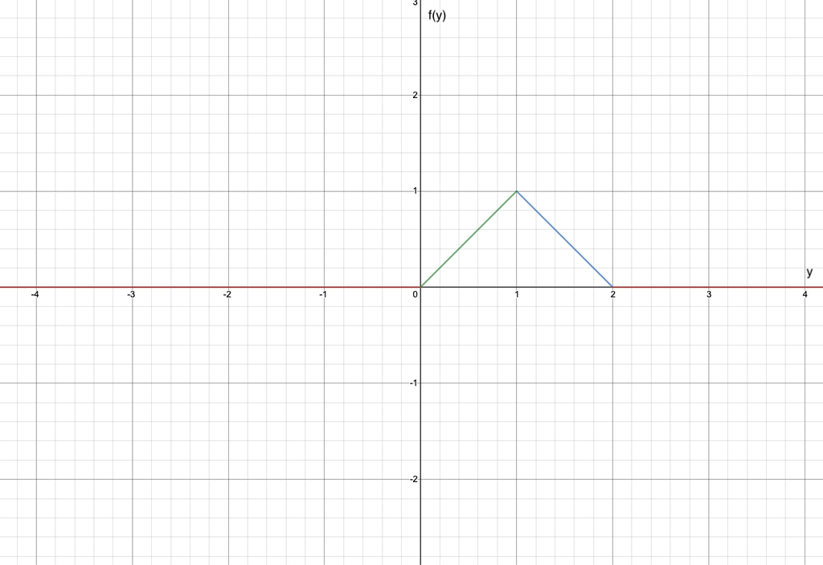

Graph of f(y)

**b.**

For $0 < y < 1$ we have,

$$\begin{aligned}
F(y)&=\int^y_{0}ydy \\
&= \frac{y^2}{2} \\
\end{aligned}$$

For $1 \le y < 2$ we have,

$$\begin{aligned}
F(y)&=2y-\frac{y^2}{2}-1
\end{aligned}$$

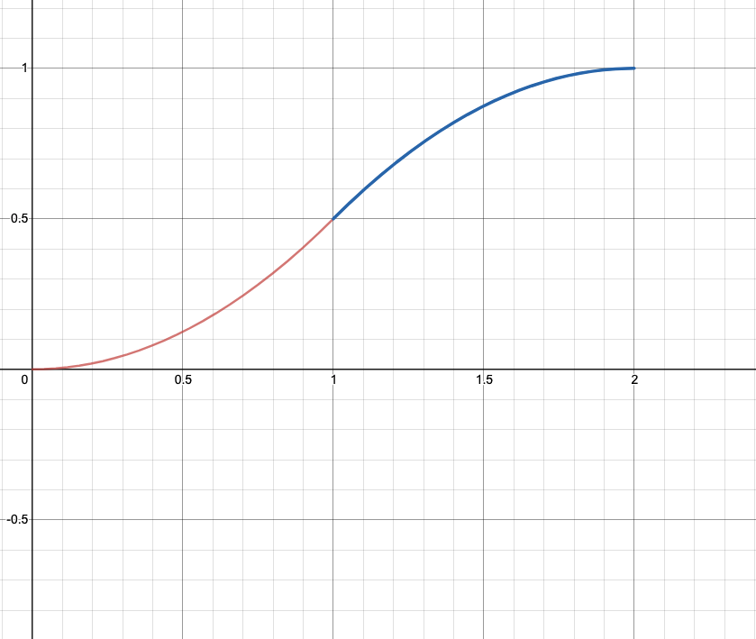

Graph

**c.**

$$\begin{aligned}
P(0.8<Y<1.2)&=P(1.2)-P(0.8) \\
&=\frac{1.2^2}{2}+2(1.2)-1-\frac{0.8^2}{2} \\
&= \boxed{0.36}
\end{aligned}$$

**d.**

$$\begin{aligned}
P(Y > 1.5 | Y > 1)&=\frac{P(Y>1.5 \cap Y > 1)}{P(Y>1)} \\
&=\frac{P(Y>1.5)}{0.5} \\
&=\frac{P(Y < 0.5)}{0.5} && \text{by symmetry we have} \\
&=\frac{0.5^3}{0.5} \\
&= \boxed{0.25}
\end{aligned}$$

## 4.18

**a.**

$$\begin{aligned}
1&=\int_{-1}^00.2\:dy+\int_0^1(0.2+cy)dy+0 \\
&=0.4+0.5c \\
c&=\boxed{1.2}
\end{aligned}$$

**b.**

$$\begin{aligned}
F(y)&=
\left\{
\begin{array}{ll}
0 & y\leq -1 \\
0.2(1+y) & -1\leq y\leq 0 \\
0.2(1+y+3y^2) & 0\leq y\leq 1 \\
1 & y > 1 \\
\end{array}
\right.
\end{aligned}$$

**c.**

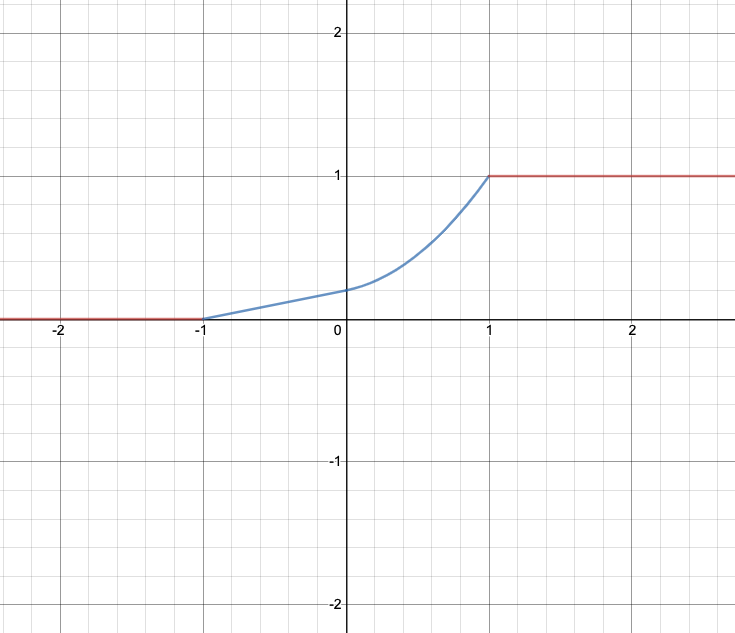

Graph of F(y)

[figure not shown]

**d.**

$$\begin{aligned}
F(-1)&=0 \\
F(0)&=0.2 \\
F(1)&=1
\end{aligned}$$

**e.**

$$\begin{aligned}
P(0 \le Y \le 0.5)&= 1-P(Y >0.5) \\
&=1-0.55 \\
&=\boxed{0.45}
\end{aligned}$$

**e.**

$$\begin{aligned}
P(Y > 0.5 | Y > 0.1)&= \frac{P(Y > 0.5 \cap Y > 0.1)}{P(Y>0.1)} \\
&=\frac{P(Y > 0.5)}{P(Y>0.1)} \\
&= \frac{0.55}{0.774} \\
&= \boxed{0.71}
\end{aligned}$$

## 4.28

**a.**

$$\begin{aligned}
1&=\int_{-\infty}^{\infty}f(y)dy \\
&=\int_{0}^{1}cy^2(1-y)^4dy \\
&=c\int_0^1(y^2-4y^3+6y^4-4y^5+y^6)\; dy \\
1&= \frac{c}{105} \\
c&=\boxed{105}
\end{aligned}$$

**b.**

$$\begin{aligned}
E[Y]&=\int_{-\infty}^{\infty}yf(y)dy \\
&= \int_0^1(y105y^2(1-y)^4) \; dy \\
&= 105\int_0^1 (y^3-4y^4+6y^5-4y^6+y^7)\:dy \\
&= 105 * \frac{1}{280} \\
&= \boxed{\frac{105}{280}}
\end{aligned}$$

## 4.32

**a.**

$$\begin{aligned}
E[Y]&=\int_{0}^{4}yf(y)dy \\
&=\int_{0}^{4}y(\frac{3}{64}y^2(4-y))dy \\
&=\frac{3}{64}\int_{0}^{4}(4y^3-y^4)dy \\
&=\frac{3}{64}*51.2 \\
&= \boxed{\frac{12}{5}}
\end{aligned}$$

$$\begin{aligned}
V(Y)&=E(Y^2)-E(Y)^2 \\
&=E(Y^2)-2.4^2 \\
E(Y^2)&=\int_{0}^{4}y^2f(y)dy \\
&=\frac{3}{64}\int_{0}^{4}(4y^4-y^5)dy \\
&=\frac{3}{64}(\frac{4(4)^5}{5}-\frac{4^6}{6}) \\
&= 6.4 \\
V(Y) &= 6.4-2.4^2 \\
&= \boxed{0.64}
\end{aligned}$$

**b.**

Given that the CPU time costs the firm $200 per hour we find the expected value as

$$\begin{aligned}
E(200Y)&=200E(Y) \\
&=200*2.4\\
&= \boxed{480}
\end{aligned}$$

and the expected variance as

$$\begin{aligned}
V(200Y)&=200^2V(Y) \\
&=200^2(0.64) \\
&=\boxed{25,600}
\end{aligned}$$

**c.**

We determine if the cost will exceed 600 by testing

$$\begin{aligned}
P(200Y>600)&=P(Y>3) \\
&=\int_3^4f(y)dy \\
&=\int_{3}^{4}(\frac{3}{64}y^2(4-y))dy \\
&= \frac{3}{64}(\frac{4}{3}(4^3-3^3)-\frac{1}{4}(4^4-3^4)) \\
&= 0.2617
\end{aligned}$$
So the cost will exceed $600 approximately 26.17% of the time which is not too often.

## 4.40

The probability based on the uniform distribution of landing past the midpoint is $\frac{1}{2}$ in 39. The probability that exactly one of the three lands past the midpoint is given by solving for the probability in a binomial distribution with parameters $n = 3$ and $p= \frac{1}{2}$. Let X be the number of parachutists that land past the midpoint (A,B)

$$\begin{aligned}
P(X=1)&=3*\frac{1}{2}^3 \\
&=\boxed{\frac{3}{8}}
\end{aligned}$$

## 4.48

**a.**

$$\begin{aligned}
P(475<Y<500)&=\int_{475}^{500}f(y)dy \\
&=\int_{475}^{500}\frac{1}{500}dy \\
&=\frac{500-475}{500} \\
&=\boxed{0.05}
\end{aligned}$$

There is a 5% chance that she selects an area within 25 feet of the end of the line.

**b.**

$$\begin{aligned}
P(0<y<25)&=\int_{0}^{25}f(y)dy \\
&=\int_{0}^{25} \frac{1}{500}dy\\
&=\frac{25-0}{500} \\
&= \boxed{0.05}
\end{aligned}$$

The probability that the point selected is within 25 feet of the beginning of the line is 5%.

**c.**

$$\begin{aligned}
P(0<y<250)&=\int_{0}^{250}f(y)dy \\
&=\int_{0}^{250}\frac{1}{500}dy \\
&=\frac{250-0}{500} \\
&= \boxed{0.5}
\end{aligned}$$

There is a 50% chance that the point is closer to the beginning of the line than to the end of the line.

## 4.50

$$\begin{aligned}
P((0<y<1) \cup (3<y<4))&=P(0<y<1)+P(3<y<4) \\
&=\int_0^1f(y)dy+\int_3^4f(y)dy \\
&=\int_0^1\frac{1}{5}dy+\int_3^4\frac{1}{5}dy \\
&=\frac{1}{5}+\frac{1}{5} \\
&= \boxed{\frac{2}{5}}
\end{aligned}$$

The probability that the center is up when the person calls is 40%.